Navigation

Joint Fit Extra Results Report

Figure guide for fit_joint_O2G_buffering_500seed

# Joint Fit Extra Results Report

**Run:** fit_joint_O2G_buffering_500seed  
**Detected mode:** fit_joint  
**Source directory:** `/share/lab_crd/lab_crd/taoli/Project/miningcloneid/oxygen/results/fit_joint_O2G_buffering_500seed/extra_results`  
**Generated at:** 2026-05-21 09:19:35 EDT

## 1. Joint Summary

Joint objective, boundary risk, and parameter-boundary diagnostics.

## Parameter Summary

One row per current active or estimated parameter across all seeds. The parameter_description column comes from the run parameter table snapshot.

| parameter | parameter_description | estimated | active_seed_count | seed_count | min_value | median_value | max_value | min_rel_dist_to_bound | boundary_status |
| --- | --- | --- | --- | --- | --- | --- | --- | --- | --- |
| alpha_o2 | soft oxygen-mediated high-ploidy growth penalty strength | TRUE | 129 | 129 | 0.500 | 1.127 | 3.616 | 0 | interior, near_lower, at_lower, near_upper |
| buffer_beta | ploidy-buffering strength for symmetric missegregation survival | TRUE | 129 | 129 | 0.260 | 0.850 | 1.650 | 0.261 | interior |
| buffer_n_exp | ploidy-buffering exponent for symmetric missegregation survival | TRUE | 129 | 129 | 3.706 | 8.243 | 9.948 | 0.001 | near_upper, interior |
| buffer_smax | maximum per-copy survival factor for symmetric buffering missegregation survival | TRUE | 129 | 129 | 0.591 | 0.806 | 0.962 | 0.038 | interior, near_upper |
| eta_o2 | ploidy-weighted oxygen demand exponent | TRUE | 129 | 129 | 1 | 1.367 | 1.979 | 0 | interior, near_lower, at_lower, near_upper |
| gamma_growth | exponent for the soft oxygen-mediated ploidy growth penalty | TRUE | 129 | 129 | 1.518 | 3.613 | 4.498 | 0.001 | interior, near_upper, near_lower |
| gamma_mu | exponent for high-ploidy hypoxia death above diploid reference | TRUE | 129 | 129 | 1.346 | 2.548 | 3.382 | 0.051 | interior |
| k_clear | true dead-cell clearance rate in day^-1 | TRUE | 129 | 129 | 3.8e-05 | 9.99e-05 | 2.75e-04 | 0.145 | interior |
| k_o_mis | half-saturation scale for death-linked missegregation amplification in day^-1 | TRUE | 129 | 129 | 1.06e-05 | 1.69e-04 | 0.017 | -1.517 | near_lower, interior |
| kappa_O | oxygen drop coefficient in the logarithmic O2 target model | TRUE | 129 | 129 | 0.100 | 1.082 | 1.200 | 0 | near_upper, interior, at_lower, near_lower |
| lam_max | maximum division rate lam_max in day^-1 | TRUE | 129 | 129 | 0.262 | 0.571 | 1.324 | -0.619 | interior, near_upper, near_lower |
| mu_hp | soft thresholded high-ploidy hypoxia death strength in day^-1 | TRUE | 129 | 129 | 2.2e-04 | 0.003 | 0.008 | 0.001 | interior, near_upper |
| n_O | Hill exponent for the oxygen-response weight | TRUE | 129 | 129 | 0.614 | 2.638 | 4.984 | 0.004 | interior, near_lower, near_upper |
| O2_crit | Hill critical oxygen scale for the oxygen-response weight | TRUE | 129 | 129 | 1.32e-04 | 0.032 | 1.618 | -2.059 | near_lower, interior |
| o2_S0 | supply-demand oxygen baseline S0 in percent O2 | TRUE | 129 | 129 | 2 | 2.451 | 5 | 0 | interior, near_lower, near_upper, at_lower, at_upper |
| p_mis_base | baseline per-chromosome missegregation probability | TRUE | 129 | 129 | 1.01e-06 | 7.39e-05 | 0.003 | 0.001 | interior, near_lower |
| p_misseg | stress-linked missegregation amplification scale | TRUE | 129 | 129 | 0.030 | 0.208 | 0.400 | 0 | interior, near_upper, at_upper |
| p_wgd | constant per-division whole-genome doubling probability | TRUE | 129 | 129 | 3e-04 | 0.001 | 0.001 | 0 | at_upper, near_upper, interior |
| qc | additive glucose/resource stress multiplier; qc=1 gives oxygen-only stress and qc=10 gives up to ten-fold co-limitation stress | TRUE | 129 | 129 | 1.403 | 7.646 | 9.997 | 3.16e-04 | interior, near_upper, near_lower |
| rho_2N | 2N cell density in cells per mm^3 | TRUE | 129 | 129 | 52865.001 | 105075.658 | 304187.934 | 0.024 | interior, near_lower |
| sigma_burden | burden log-normal observation SD | TRUE | 129 | 129 | 0.573 | 0.599 | 0.600 | 0 | at_upper, near_upper |

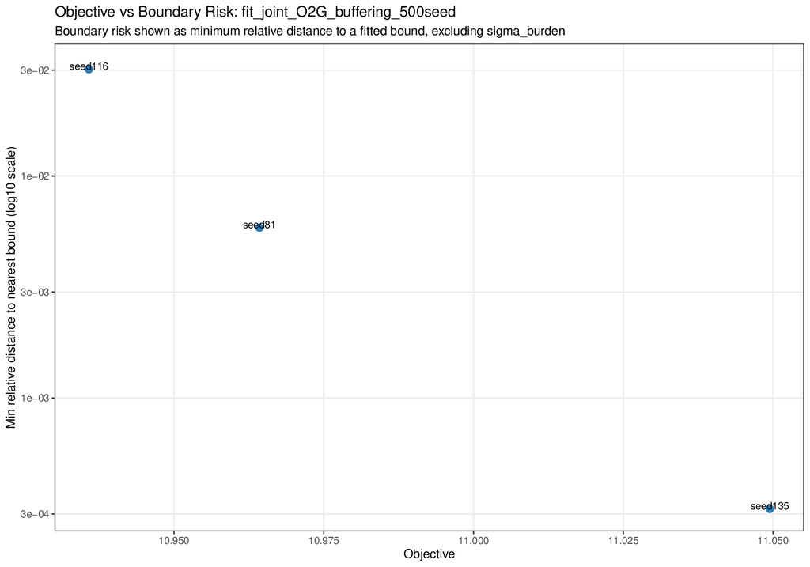

## Figure 1. Objective vs Boundary Risk

Objective score against minimum relative distance to the nearest fitted parameter bound.

`objective_vs_boundary_risk.pdf`

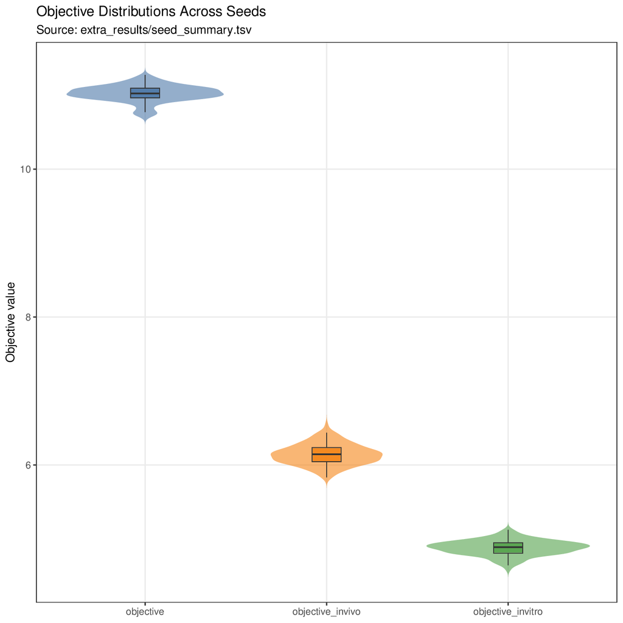

## Figure 2. Objective Components Violin

Across-seed distributions of joint total objective, in vivo objective, and in vitro objective.

`objective_components_violin.pdf`

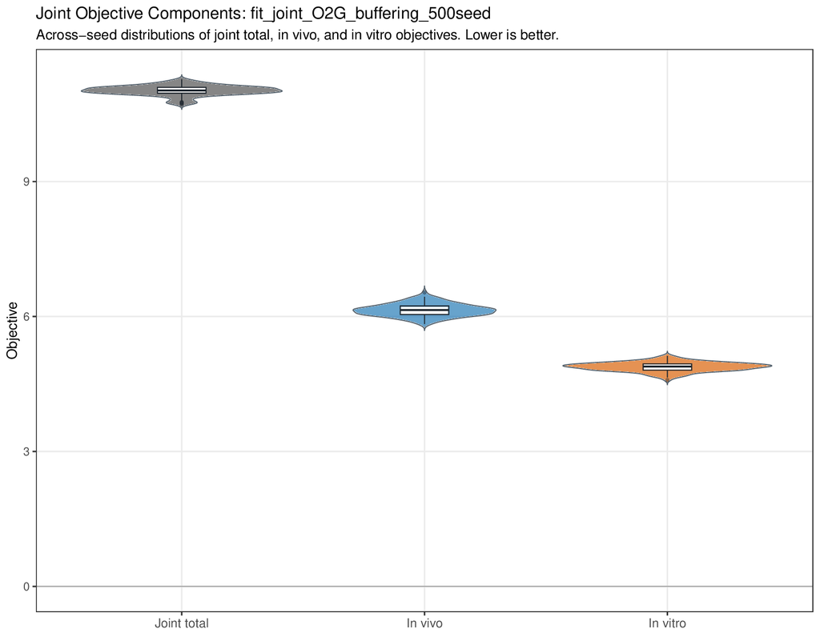

## Figure 3. Joint Objective Components

Across-seed violin and boxplot distributions of joint total objective, in vivo objective, and in vitro objective.

`joint_objective_components.pdf`

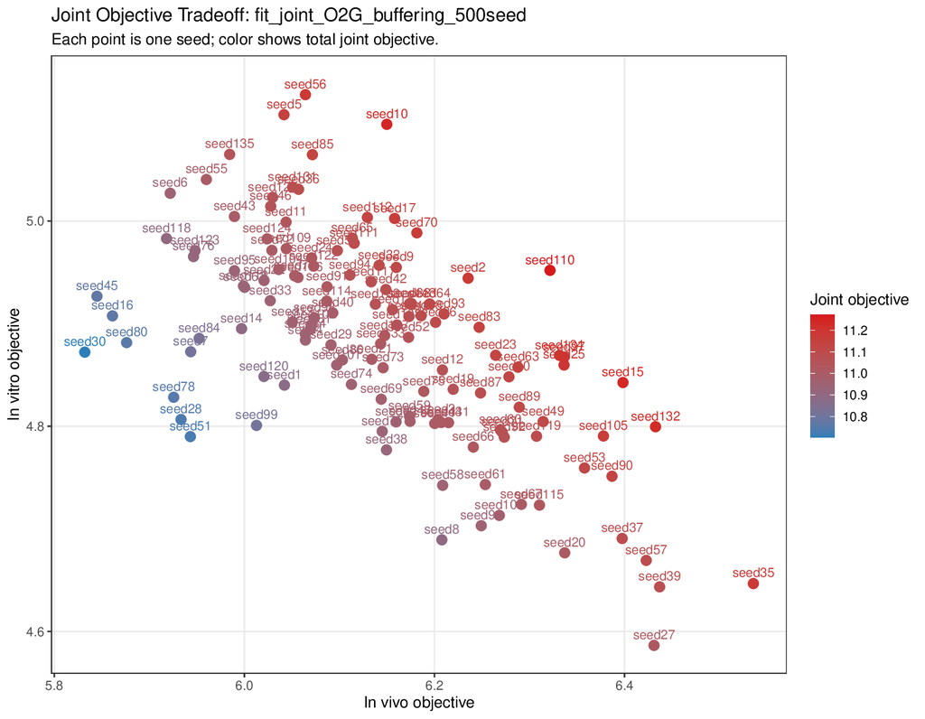

## Figure 4. Joint In Vivo vs In Vitro Objective Tradeoff

Seed-level in vivo objective against in vitro objective; color shows total joint objective.

`joint_objective_tradeoff.pdf`

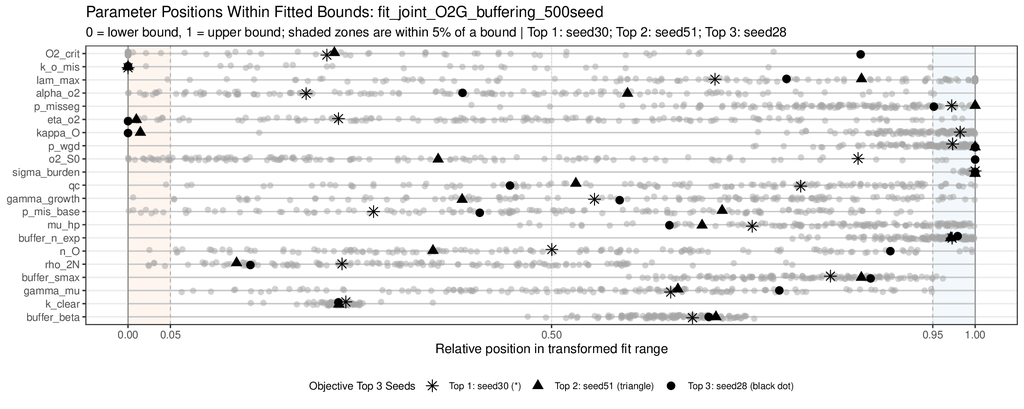

## Figure 5. Parameter Boundary Forest

Relative fitted positions of active parameters within their transformed bounds across all seeds. Highlighted seeds are the top 3 by raw objective.

`parameter_boundary_forest.pdf`

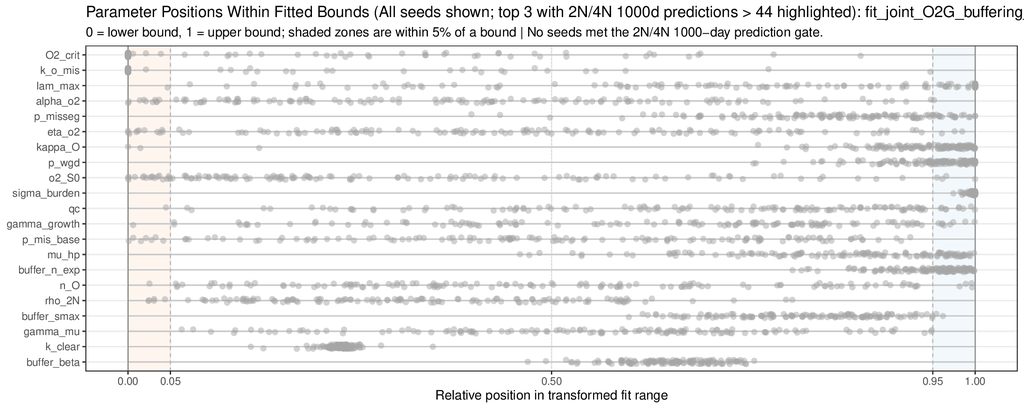

## Figure 6. Parameter Boundary Forest (Pred1000 > 44 Top 3)

Boundary forest shows all seeds; the highlighted seeds are the top eligible seeds. Eligibility requires all final 2N and 4N 1000-day predictions to be above 44; eligible seeds are ordered by raw objective. No eligible seeds were found.

`parameter_boundary_forest_pred1000_gt44_top3.pdf`

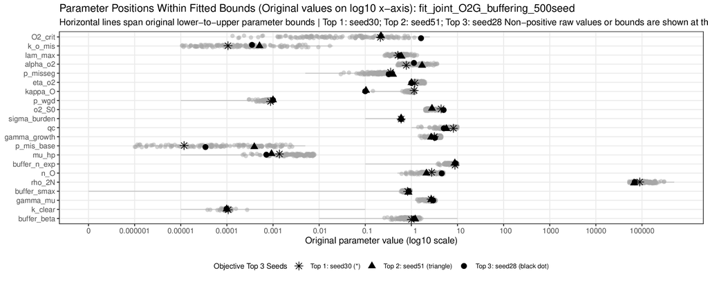

## Figure 7. Parameter Boundary Forest (Log X Scale)

Original fitted parameter values across all seeds on a log10 x-axis. Highlighted seeds are the top 3 by raw objective. Horizontal lines span original lower-to-upper parameter bounds; non-positive raw values or bounds are floored and labeled 0.

`parameter_boundary_forest_log_x.pdf`

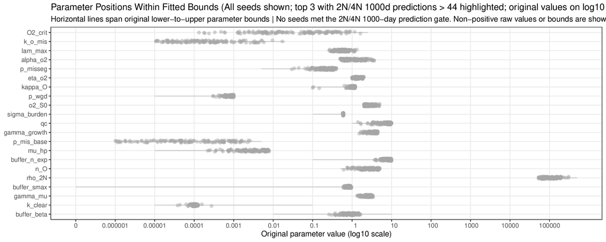

## Figure 8. Parameter Boundary Forest (Pred1000 > 44 Top 3, Log X Scale)

Boundary forest shows all seeds; the highlighted seeds are the top eligible seeds. Eligibility requires all final 2N and 4N 1000-day predictions to be above 44; eligible seeds are ordered by raw objective. No eligible seeds were found. The x-axis shows original fitted parameter values on a log10 scale; non-positive raw values or bounds are floored and labeled 0.

`parameter_boundary_forest_pred1000_gt44_top3_log_x.pdf`

## 2. In Vivo

Cross-seed in vivo prediction figures generated from the joint-fit seed outputs.

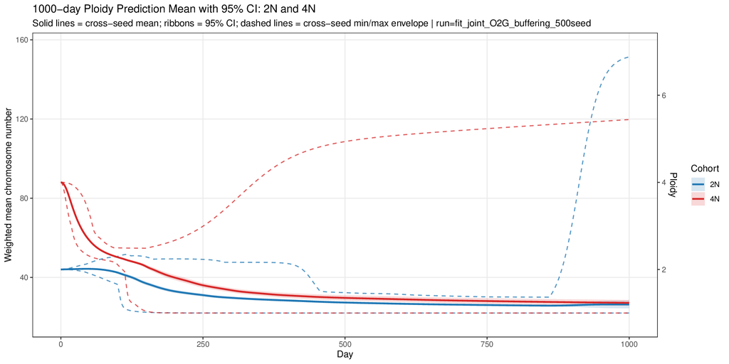

## Figure 9. Cross-seed 1000-day Ploidy Prediction: 2N and 4N

Mean trajectories and 95% confidence intervals across seed-level scenario means. Dashed lines show the cross-seed min/max envelope; the right y-axis reports ploidy.

`predict1000_ploidy_mean_ci_2N_4N.pdf`

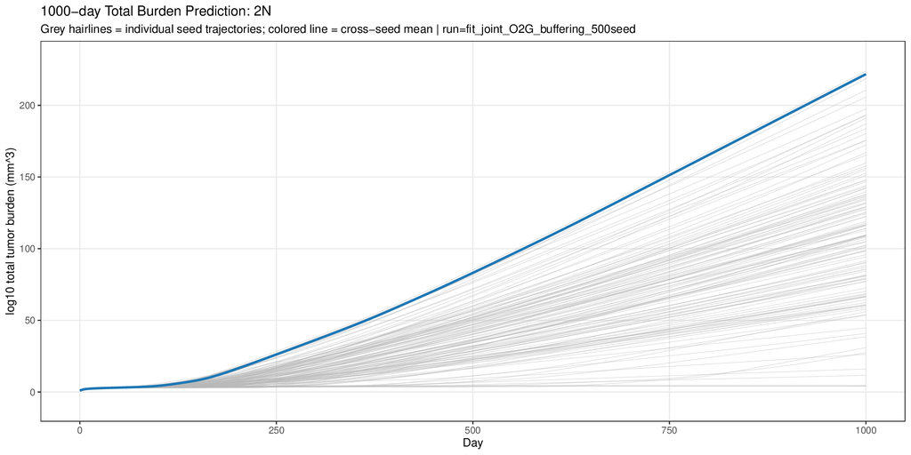

## Figure 10. Cross-seed 1000-day Total Burden Prediction: 2N

All seed-level scenario-mean total-burden trajectories are drawn as thin grey lines on the log10 scale. The colored solid line is the cross-seed mean.

`predict1000_burden_total_log_seed_mean_2N.pdf`

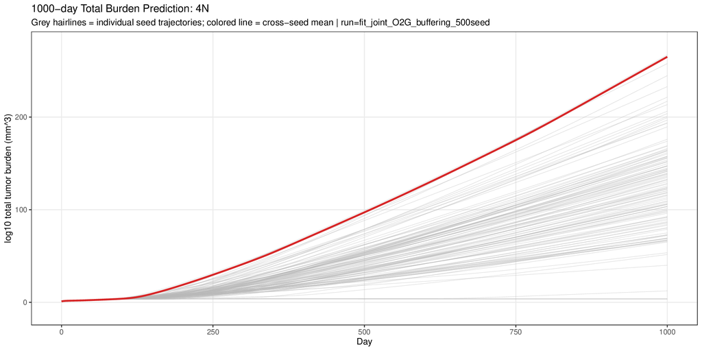

## Figure 11. Cross-seed 1000-day Total Burden Prediction: 4N

All seed-level scenario-mean total-burden trajectories are drawn as thin grey lines on the log10 scale. The colored solid line is the cross-seed mean.

`predict1000_burden_total_log_seed_mean_4N.pdf`

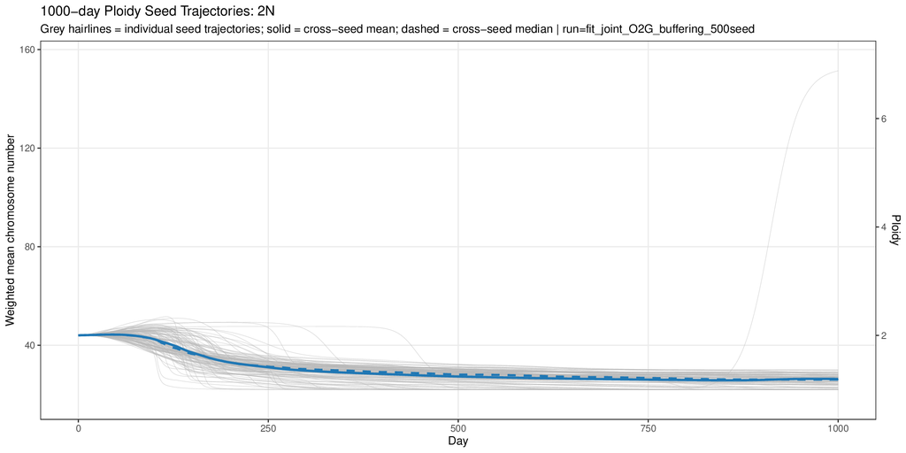

## Figure 12. Cross-seed 1000-day Ploidy Seed Trajectories: 2N

All seed-level scenario-mean trajectories are drawn as thin grey lines. The colored solid line is the cross-seed mean and the colored dashed line is the cross-seed median.

`predict1000_ploidy_seed_curves_2N.pdf`

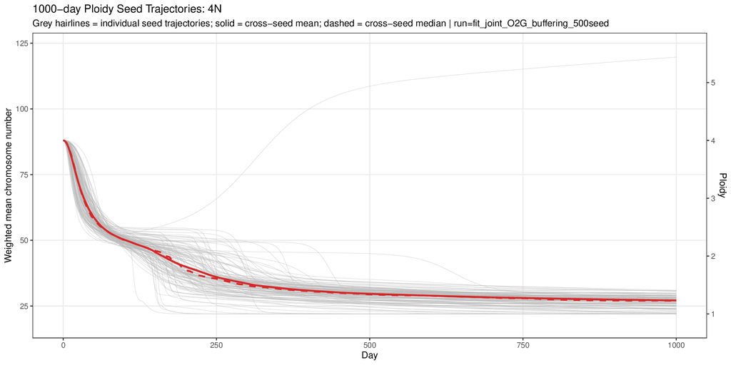

## Figure 13. Cross-seed 1000-day Ploidy Seed Trajectories: 4N

All seed-level scenario-mean trajectories are drawn as thin grey lines. The colored solid line is the cross-seed mean and the colored dashed line is the cross-seed median.

`predict1000_ploidy_seed_curves_4N.pdf`

## 3. In Vitro

In vitro summary figures generated from the joint-fit in vitro components and seed outputs.

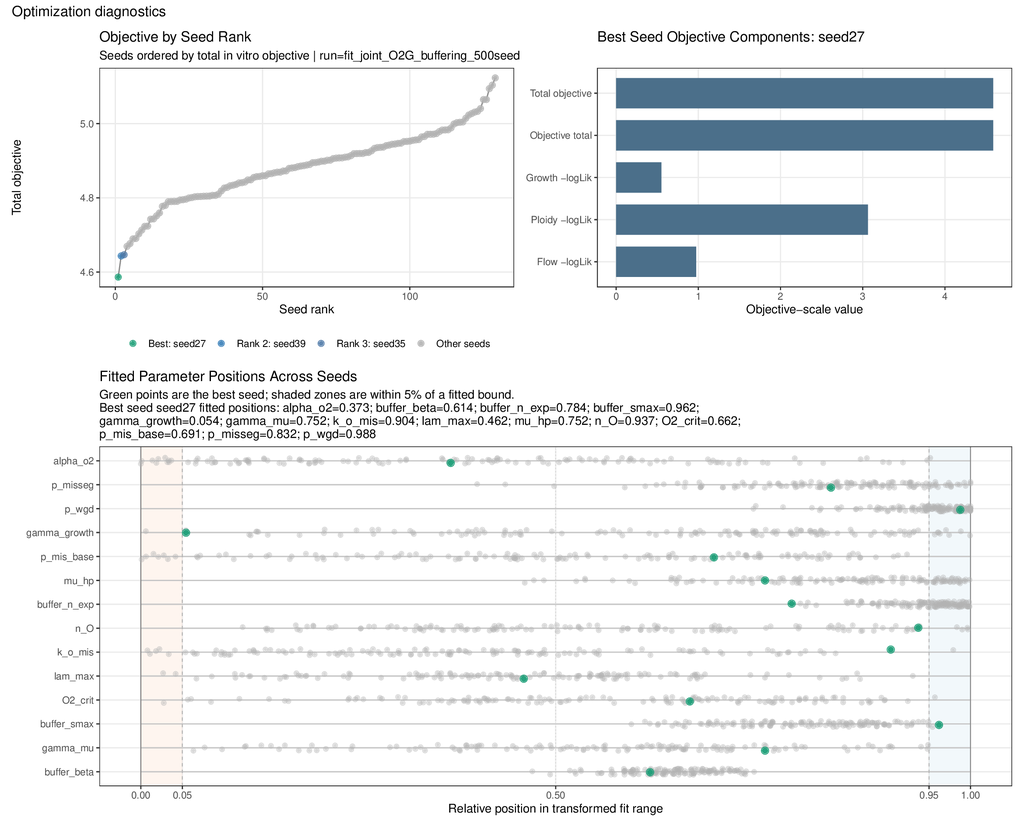

## Figure 14. Optimization Diagnostics

All-seed in vitro optimization diagnostics using the joint-fit in vitro objective for seed ordering.

`optimization_diagnostics.pdf`

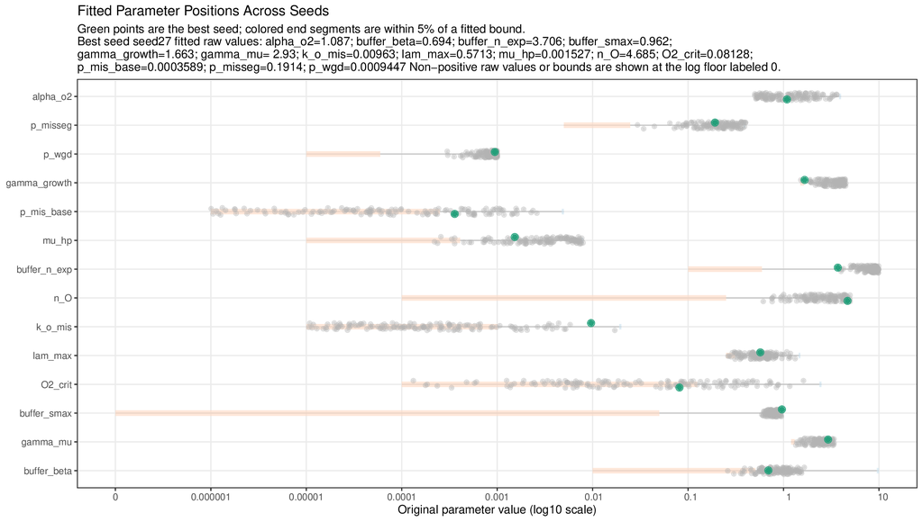

## Figure 15. Fitted Parameter Positions (Log X Scale)

All-seed joint-fit in vitro fitted-parameter positions shown as original parameter values on a log10 x-axis. This is the parameter panel from Optimization Diagnostics only; non-positive raw values or bounds are floored and labeled 0.

`invitro_parameter_positions_log_x.pdf`

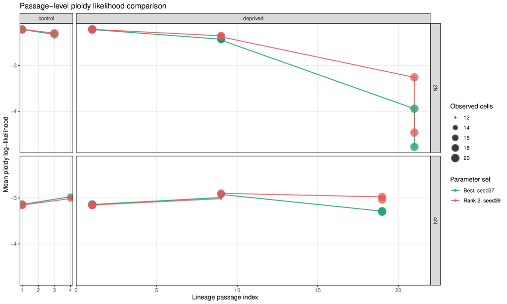

## Figure 16. Best-Fit Ploidy Likelihood Comparison

Passage-level ploidy likelihood comparison for the best available seed-level parameter sets.

`best_fit_ploidy_likelihood_comparison.pdf`

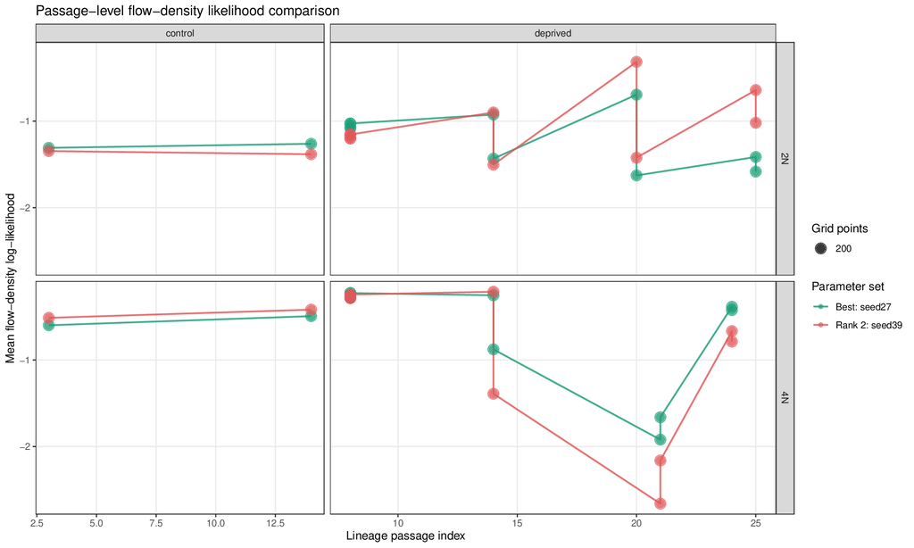

## Figure 17. Best-Fit Flow-Density Likelihood Comparison

Passage-level processed flow-density likelihood comparison for the best available seed-level parameter sets.

`best_fit_flow_likelihood_comparison.pdf`

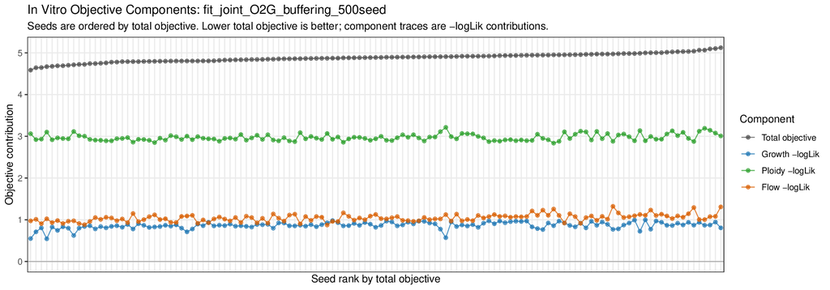

## Figure 18. In Vitro Objective Components

Seed-level total in vitro objective and growth, ploidy, and flow negative log-likelihood contributions. Lower total objective is better.

`invitro_objective_components.pdf`

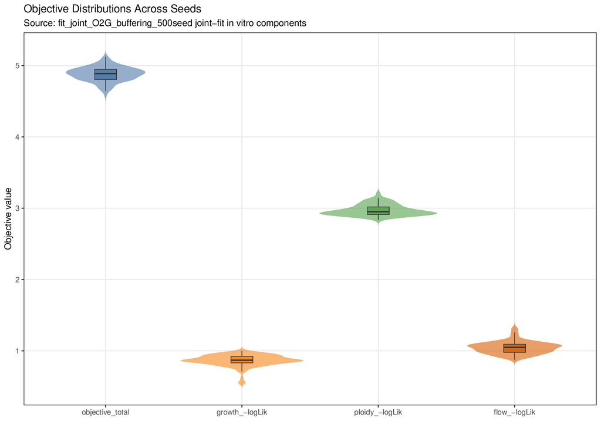

## Figure 19. In Vitro Objective Component Distributions

Across-seed distributions of the total in vitro objective and the in vitro growth, ploidy, and flow negative log-likelihood components.

`invitro_objective_components_violin.pdf`

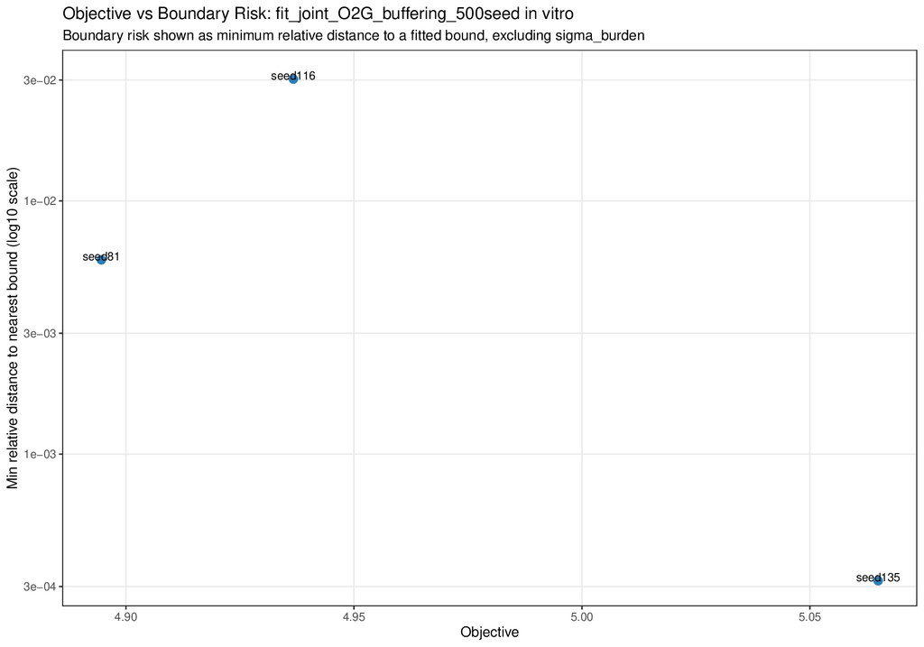

## Figure 20. In Vitro Objective vs Boundary Risk

Total in vitro objective against minimum relative distance to the nearest fitted parameter bound.

`invitro_objective_vs_boundary_risk.pdf`

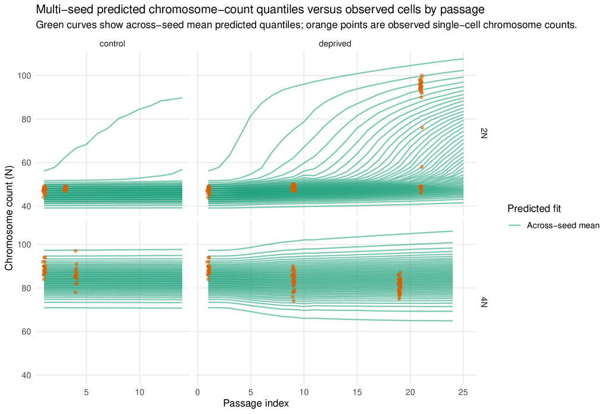

## Figure 21. Multi-Seed Predicted Chromosome-Count Quantiles vs Observed Cells

Across-seed version of the predicted chromosome-count quantile timecourse shown in simulation_basics.html. Panels are split by 2N/4N and control/deprived; green curves show predicted quantiles by passage and orange points show observed single cells.

`invitro_karyotype_quantiles_multiseed.pdf`